# Cardiopulmonary Bypass (CPB) Response Analysis in Tetralogy of Fallot (ToF) and Atrial Septal Defect (ASD)

Sara Tahir

2026-04-13

## Project Overview

This pipeline analyzes the transcriptomic response to cardiopulmonary bypass (CPB) in pediatric patients with Tetralogy of Fallot (ToF) and Atrial Septal Defect (ASD) stratified by sex.

**Platform:** Affymetrix Human Genome U133 Plus PM Array (GSE132176)

**Design:** Paired samples (Pre-CPB and Post-CPB) from the same individuals.

## Setup and Read data

```r
# Load/Install Manager
if (!require("pacman")) install.packages("pacman")
pacman::p_load(
  tidyverse, gplots, here,      # CRAN
  GEOquery, oligo, limma, edgeR, hthgu133pluspm.db, sva # Bioconductor
)
```

```r
# Read in geo dataset
geo_data <- getGEO(filename = "GSE132176_series_matrix.txt.gz")
metadata <- pData(geo_data)

cel_files <- list.celfiles(path = "GSE132176_RAW", full.names = TRUE)
file_gsms <- stringr::str_extract(cel_files, "GSM[0-9]+")
ordered_files <- cel_files[match(metadata$geo_accession, file_gsms)]
raw_data <- read.celfiles(ordered_files)
```

```
## Reading in : GSE132176_RAW/GSM3852123_H09_POST-CEC_TOF.cel
## Reading in : GSE132176_RAW/GSM3852124_H09_PRE-CEC_TOF.cel
## Reading in : GSE132176_RAW/GSM3852125_H111_POST-CEC_TOF.cel
## Reading in : GSE132176_RAW/GSM3852126_H111_PRE-CEC_TOF.cel
## Reading in : GSE132176_RAW/GSM3852127_H115_POST-CEC_TOF.cel
## Reading in : GSE132176_RAW/GSM3852128_H115_PRE-CEC_TOF.cel
## Reading in : GSE132176_RAW/GSM3852129_H119_POST-CEC_TOF.cel
## Reading in : GSE132176_RAW/GSM3852130_H119_PRE-CEC_TOF.cel
## Reading in : GSE132176_RAW/GSM3852131_H139_POST-CEC_TOF.cel
## Reading in : GSE132176_RAW/GSM3852132_H139_PRE-CEC_TOF.cel
## Reading in : GSE132176_RAW/GSM3852133_H175_POST-CEC_ASD.cel
## Reading in : GSE132176_RAW/GSM3852134_H175_PRE-CEC_ASD.cel
## Reading in : GSE132176_RAW/GSM3852135_H177_POST-CEC_ASD.cel
## Reading in : GSE132176_RAW/GSM3852136_H177_PRE-CEC_ASD.cel
## Reading in : GSE132176_RAW/GSM3852137_H204_POST-CEC_TOF.cel
## Reading in : GSE132176_RAW/GSM3852138_H204_PRE-CEC_TOF.cel
## Reading in : GSE132176_RAW/GSM3852139_H227_POST-CEC_ASD.cel
## Reading in : GSE132176_RAW/GSM3852140_H227_PRE-CEC_ASD.cel
## Reading in : GSE132176_RAW/GSM3852141_H255_POST-CEC_ASD.cel
## Reading in : GSE132176_RAW/GSM3852142_H255_PRE-CEC_ASD.cel
## Reading in : GSE132176_RAW/GSM3852143_H27_POST-CEC_ASD.cel
## Reading in : GSE132176_RAW/GSM3852144_H27_PRE-CEC_ASD.cel
## Reading in : GSE132176_RAW/GSM3852145_H313_POST-CEC_ASD.cel
## Reading in : GSE132176_RAW/GSM3852146_H313_PRE-CEC_ASD.cel
## Reading in : GSE132176_RAW/GSM3852147_H315_POST-CEC_TOF.cel
## Reading in : GSE132176_RAW/GSM3852148_H315_PRE-CEC_TOF.cel
## Reading in : GSE132176_RAW/GSM3852149_H34_POST-CEC_TOF.cel
## Reading in : GSE132176_RAW/GSM3852150_H34_PRE-CEC_TOF.cel
## Reading in : GSE132176_RAW/GSM3852151_H344_POST-CEC_ASD.cel
## Reading in : GSE132176_RAW/GSM3852152_H344_PRE-CEC_ASD.cel
## Reading in : GSE132176_RAW/GSM3852153_H361_POST-CEC_ASD.cel
## Reading in : GSE132176_RAW/GSM3852154_H361_PRE-CEC_ASD.cel
## Reading in : GSE132176_RAW/GSM3852155_H62_POST-CEC_ASD.cel
## Reading in : GSE132176_RAW/GSM3852156_H62_PRE-CEC_ASD.cel
## Reading in : GSE132176_RAW/GSM3852157_H71_POST-CEC_TOF.cel
## Reading in : GSE132176_RAW/GSM3852158_H71_PRE-CEC_TOF.cel
## Reading in : GSE132176_RAW/GSM3852159_H76_POST-CEC_TOF.cel
## Reading in : GSE132176_RAW/GSM3852160_H76_PRE-CEC_TOF.cel
## Reading in : GSE132176_RAW/GSM3852161_H96_POST-CEC_ASD.cel
## Reading in : GSE132176_RAW/GSM3852162_H96_PRE-CEC_ASD.cel
```

## Pre-Processing and Normalization

Use the **Robust Multi-array Average (RMA)** algorithm to perform background subtraction, quantile normalization, and log2 summarization. *(Note: Unable to filter based on PA calls (Presence/Absence) because “this is a PM-only array, so MAS5-style P/A calls are not applicable.”*

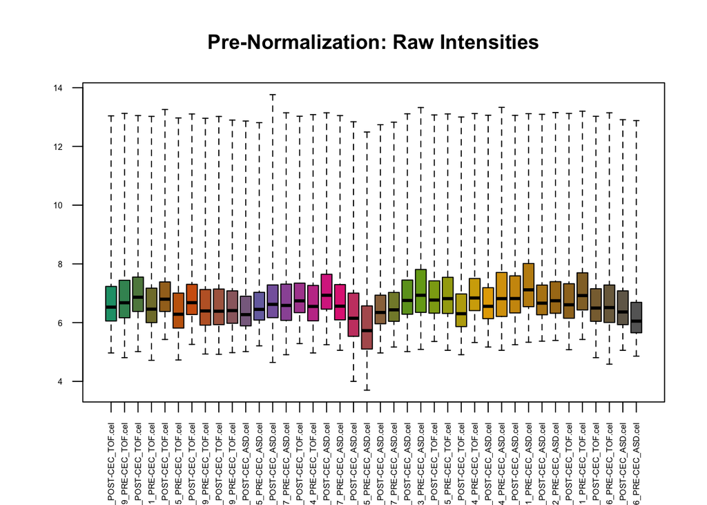

```r
# Pre-RMA Distribution Check
boxplot(raw_data, target = "core", main = "Pre-Normalization: Raw Intensities", las = 2, cex.axis = 0.5)
```

```r
# Use RMA to do background subtraction, normalization, and summarization
eset <- rma(raw_data)
```

```
## Background correcting
## Normalizing
## Calculating Expression
```

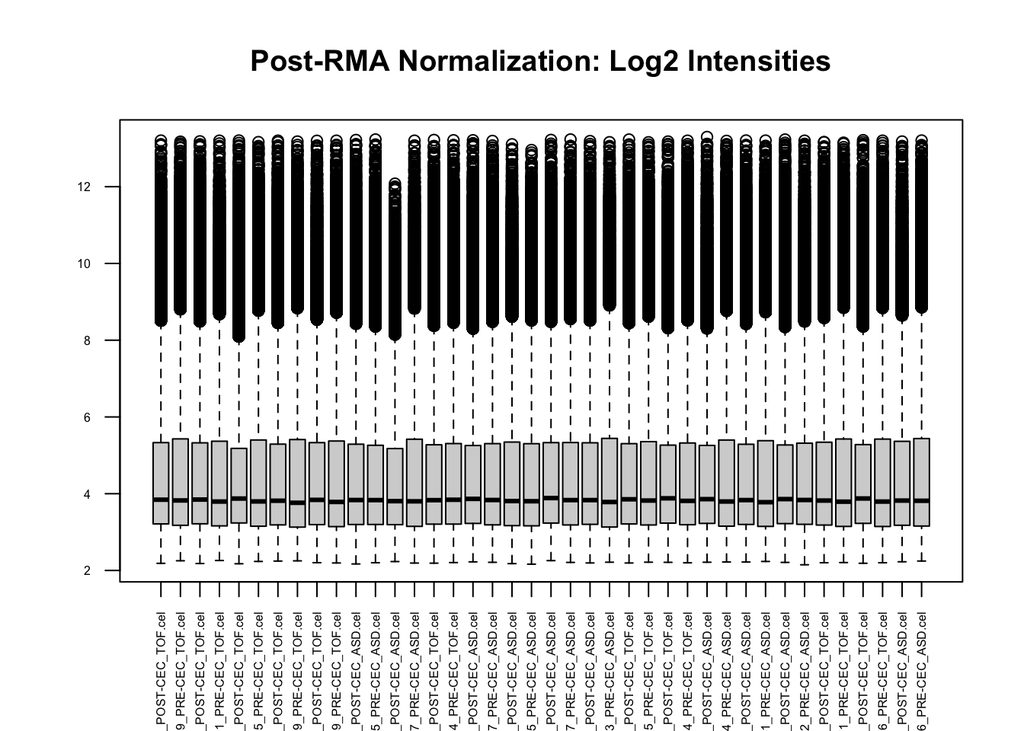

```r
# Get ExpressionFeatureSet
expression_matrix <- exprs(eset)
# Post-RMA Distribution Check
boxplot(expression_matrix, main = "Post-RMA Normalization: Log2 Intensities", las = 2, cex.axis = 0.5)
```

## Intensity Filtering

To increase power, drop probes that are mostly just background noise. Filter by expression cannot be used because this is microarray data, so instead check to make sure a gene is expressed above the noise in at least n patients, n being the smallest group size

```r
min_samples <- 4 # ASD males are the smallest group size

noise_threshold <- median(expression_matrix) # Can also use log(10) value
is_expressed <- expression_matrix > noise_threshold
keep_probes <- rowSums(is_expressed) >= min_samples

expression_matrix_filtered <- expression_matrix[keep_probes, ]

# Check how many probes were removed
total_probes <- nrow(expression_matrix)
kept_probes <- nrow(expression_matrix_filtered)
removed_probes <- total_probes - kept_probes

cat("Total starting probes:", total_probes, "\n")
```

```
## Total starting probes: 54715
```

```r
cat("Probes kept:", kept_probes, paste0("(", round((kept_probes/total_probes)*100, 1), "%)"), "\n")
```

```
## Probes kept: 32145 (58.7%)
```

```r
cat("Probes removed (Noise):", removed_probes, paste0("(", round((removed_probes/total_probes)*100, 1), "%)"), "\n")
```

```
## Probes removed (Noise): 22570 (41.3%)
```

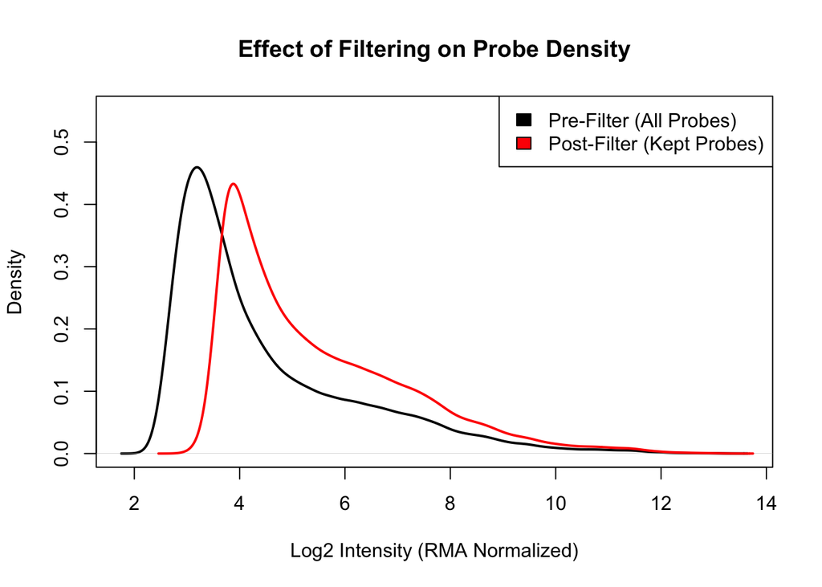

```r
# Create plot to view data before and after filtering
pre_filter_means <- rowMeans(expression_matrix)
post_filter_means <- rowMeans(expression_matrix_filtered)

plot(density(pre_filter_means),
     main = "Effect of Filtering on Probe Density",
     xlab = "Log2 Intensity (RMA Normalized)",
     col = "black",
     lwd = 2,
     ylim = c(0, max(density(pre_filter_means)$y) * 1.2)) # Gives a little headroom

lines(density(post_filter_means), col = "red", lwd = 2)

legend("topright",
       legend = c("Pre-Filter (All Probes)", "Post-Filter (Kept Probes)"),
       fill = c("black", "red"))
```

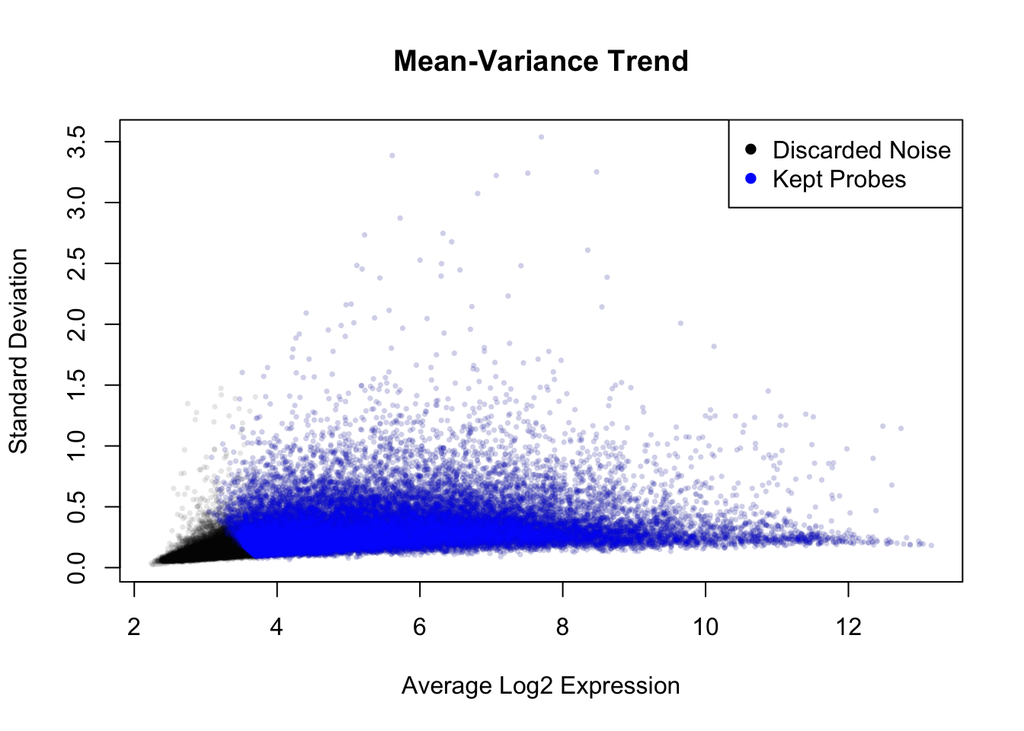

```r
# Plot Mean vs Variance
pre_mean <- rowMeans(expression_matrix)
pre_sd <- apply(expression_matrix, 1, sd)

plot(pre_mean, pre_sd,
     pch = 16, cex = 0.5, col = rgb(0,0,0,0.1), # Transparent black dots
     main = "Mean-Variance Trend",
     xlab = "Average Log2 Expression",
     ylab = "Standard Deviation")

# Highlight the kept probes in blue
points(pre_mean[keep_probes], pre_sd[keep_probes],
       pch = 16, cex = 0.5, col = rgb(0,0,1,0.1))

legend("topright", legend=c("Discarded Noise", "Kept Probes"),
       col=c("black", "blue"), pch=16)
```

## Annotation of Genes

```r
# Label genes
gene_symbols <- mapIds(hthgu133pluspm.db,
                      keys = rownames(expression_matrix_filtered),
                      column = "SYMBOL",
                      keytype = "PROBEID",
                      multiVals = "first")
# Filter out probes that don't map to any known gene (NAs)
valid_probes <- !is.na(gene_symbols)
expression_matrix_filtered <- expression_matrix_filtered[valid_probes, ]
hgnc_symbols_filtered <- gene_symbols[valid_probes]
```

## Transcriptomic Sex Identification

Metadata in this dataset lacks male/female designation, so to distinguish between males and females the expression of the following genes was analyzed.

Female only: XIST

Male only: KDM5D, RPS4Y1, NLGN4Y, EIF1AY

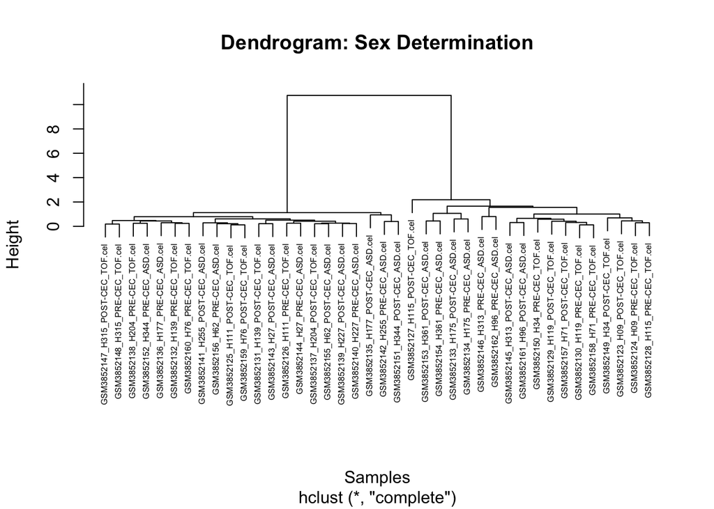

```r
# Create a temporary collapsed matrix just for the sex calculation math
temp_annotated <- avereps(expression_matrix_filtered, ID = hgnc_symbols_filtered)

sex_genes <- c("XIST", "KDM5D", "RPS4Y1", "EIF1AY", "NLGN4Y")
available_sex_genes <- sex_genes[sex_genes %in% rownames(temp_annotated)]

# Subset matrix to contain just sex genes and transpose so that samples are rows
sex_matrix <- t(temp_annotated[available_sex_genes, ])

# Hierarchical clustering
dist_sex <- dist(sex_matrix)
hclust_sex <- hclust(dist_sex)

plot(hclust_sex, main="Dendrogram: Sex Determination", xlab="Samples", cex=0.5)
```

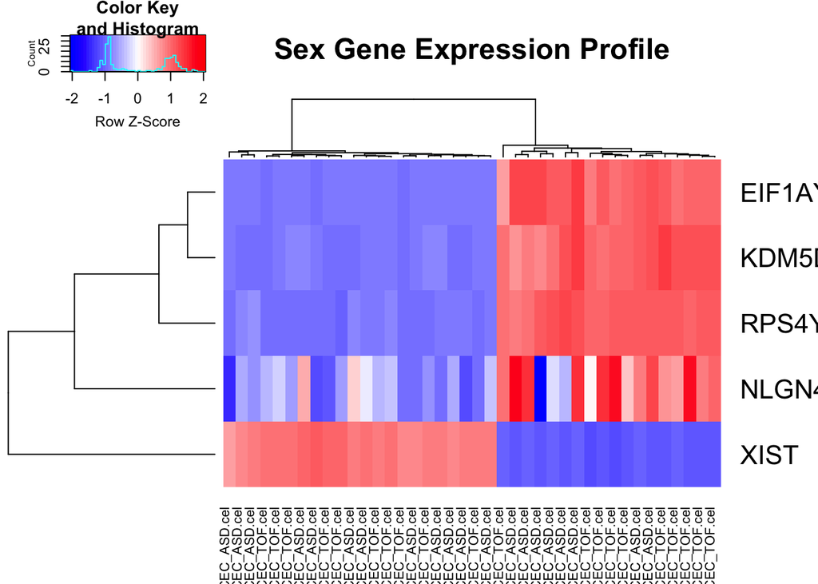

```r
heatmap.2(t(sex_matrix),
          trace = "none", scale = "row",
          col = colorRampPalette(c("blue", "white", "red"))(50),
          main = "Sex Gene Expression Profile")
```

```r
clusters <- cutree(hclust_sex, k = 2)

# Calculate the mean XIST expression for both clusters
xist_c1 <- mean(sex_matrix[clusters == 1, "XIST"])
xist_c2 <- mean(sex_matrix[clusters == 2, "XIST"])

# The cluster with the higher XIST expression is Female
female_cluster <- ifelse(xist_c1 > xist_c2, 1, 2)

# Build the final sex dataframe for the pipeline
sexDf <- data.frame(
  sampleID = rownames(sex_matrix),
  Cluster = clusters
) %>%
  mutate(
    # Clean up the sample IDs to match metadata
    sampleID = gsub("^(GSM[0-9]+)_.*$", "\\1", basename(sampleID)),
    # Assign the text labels
    transcriptomicSex = ifelse(Cluster == female_cluster, "Female", "Male")
  )
```

## Metadata formatting

```r
metadata$sampleID <- rownames(metadata)

# Merge sex and create clean factors
metadata <- metadata %>%
  left_join(sexDf %>% dplyr::select(sampleID, transcriptomicSex), by = c("geo_accession" = "sampleID")) %>%
  mutate(
    Time = factor(ifelse(grepl("before", `time:ch1`), "Pre", "Post"), levels = c("Pre", "Post")),
    Disease = factor(`disease state:ch1`),
    PatientID = factor(gsub("patient ", "Pt", `individual:ch1`)),
    Sex = factor(transcriptomicSex)
  )

# Apply clean names (e.g., "TOF_Pre_Male_Pt1")
clean_sample_names <- paste(metadata$Disease, metadata$Time, metadata$Sex, metadata$PatientID, sep = "_")
colnames(expression_matrix_filtered) <- clean_sample_names
rownames(metadata) <- clean_sample_names

# Add scan dates and scan years to metadata
raw_dates <- protocolData(raw_data)$dates
metadata$ScanDate <- as.factor(as.Date(raw_dates, format = "%Y/%m/%d"))
metadata$ScanYear <- as.factor(format(as.Date(raw_dates, format = "%Y/%m/%d"), "%Y"))
metadata$SampleGroup <- paste(metadata$Disease, metadata$Time, sep = "_")
```

## Sample Quality Control

Used hierarchical clustering and PCA plots *(Note: Unable to unable to create NUSE/RLE plots because R crashes upon calling fitProbeLevelModel)“*U

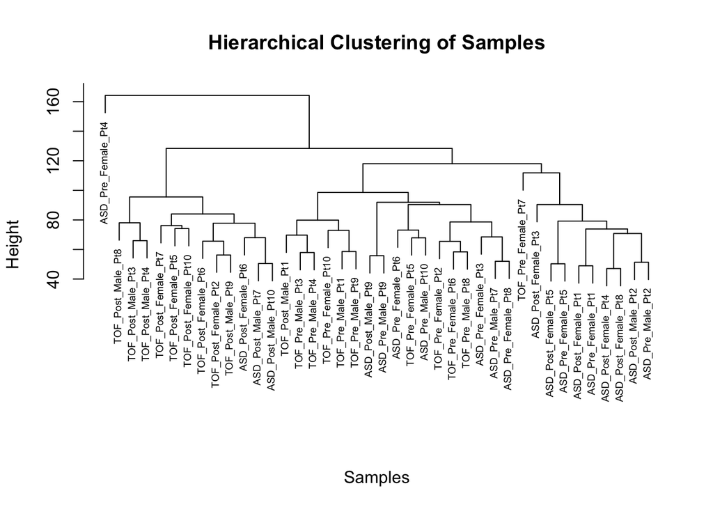

```r
# Hierarchical clustering
dist_mat <- dist(t(expression_matrix_filtered))
hclust_res <- hclust(dist_mat)
plot(hclust_res,
     main = "Hierarchical Clustering of Samples",
     xlab = "Samples",
     sub = "",
     cex = 0.6) # cex shrinks the text so patient IDs don't overlap as badly
```

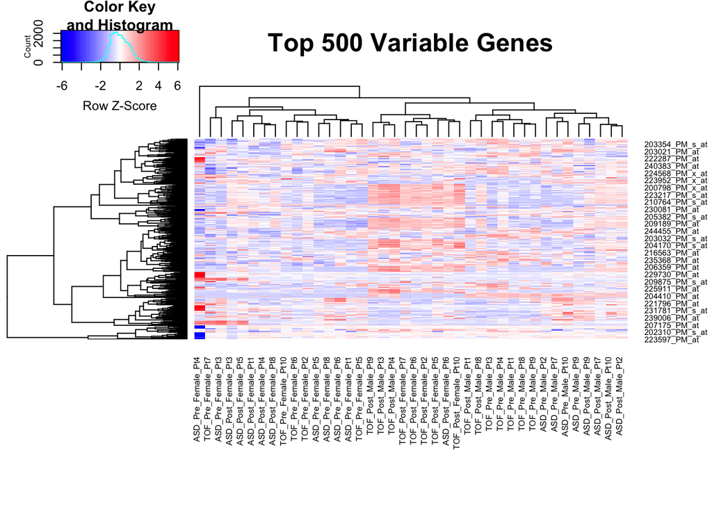

```r
# Heatmap of top variable genes
# Calculate variance for all genes across all samples
gene_vars <- apply(expression_matrix_filtered, 1, var)
# Grab top 500 genes
top_var_genes <- names(sort(gene_vars, decreasing = TRUE))[1:500]

heatmap.2(expression_matrix_filtered[top_var_genes, ],
          trace = "none",
          scale = "row",          # Scales the colors per gene (row) so extremes don't wash out the plot
          col = colorRampPalette(c("blue", "white", "red"))(50),
          main = "Top 500 Variable Genes",
          cexCol = 0.6,
          margins = c(10, 5))
```

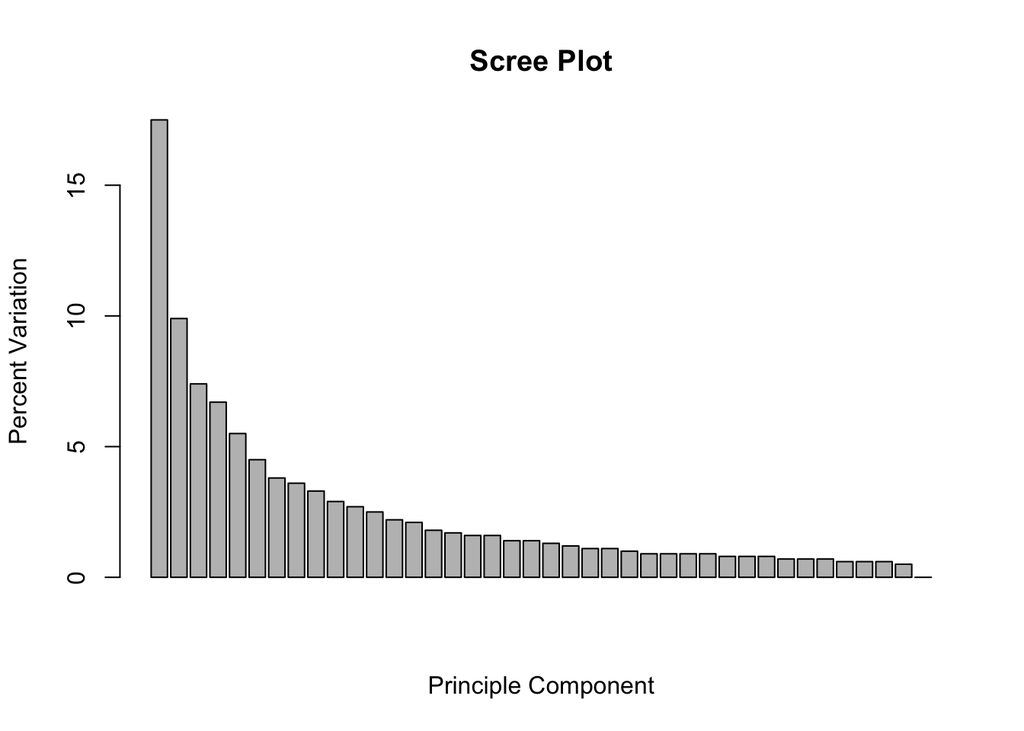

```r
# PCA Plot
pca_res <- prcomp(t(expression_matrix_filtered), scale. = TRUE)
pca_df <- as.data.frame(pca_res$x)
pca_plot_data <- cbind(pca_df, metadata)

pca_res.var <- pca_res$sdev^2
pca_res.var.per <- round(pca_res.var/sum(pca_res.var)*100,1)
barplot(pca_res.var.per, main = "Scree Plot", xlab = "Principle Component", ylab = "Percent Variation")
```

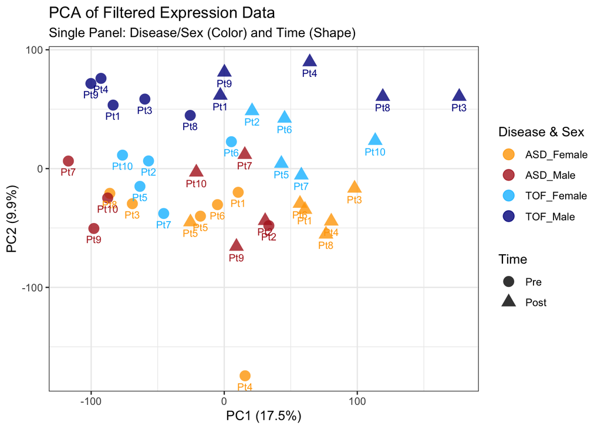

```r
# Create a combined grouping variable for the colors
pca_plot_data$Disease_Sex <- paste(pca_plot_data$Disease, pca_plot_data$Sex, sep = "_")

ggplot(pca_plot_data, aes(x = PC1, y = PC2, color = Disease_Sex, shape = Time)) +
  geom_point(size = 4, alpha = 0.8) +
  geom_text(aes(label = PatientID), vjust = 2, size = 3, show.legend = FALSE) +
  theme_bw() +

  # Assign complementary light/dark shades so the diseases group visually
  scale_color_manual(
    name = "Disease & Sex",
    values = c(
      "ASD_Female" = "orange",
      "ASD_Male" = "firebrick",
      "TOF_Female" = "deepskyblue",
      "TOF_Male" = "darkblue"
    )
  ) +

  labs(
    title = "PCA of Filtered Expression Data",
    subtitle = "Single Panel: Disease/Sex (Color) and Time (Shape)",
    x = paste0("PC1 (", round(summary(pca_res)$importance[2,1] * 100, 1), "%)"),
    y = paste0("PC2 (", round(summary(pca_res)$importance[2,2] * 100, 1), "%)")
  )
```

## Batch Effect Assessment

Physical scan dates were extracted to assess temporal batch effects.

```r
table(Group = metadata$SampleGroup, Date = metadata$ScanDate)
```

```
##           Date
## Group      2013-03-05 2013-03-21 2013-03-27 2013-03-28 2013-04-11 2013-05-07
##   ASD_Post          1          0          0          0          0          0
##   ASD_Pre           1          0          1          0          2          2
##   TOF_Post          0          0          0          0          0          0
##   TOF_Pre           0          2          3          1          0          0
##           Date
## Group      2014-01-24 2014-02-26 2014-02-28 2014-05-23 2014-06-17 2014-06-26
##   ASD_Post          3          1          1          1          0          1
##   ASD_Pre           0          0          0          1          0          1
##   TOF_Post          1          3          2          2          0          2
##   TOF_Pre           0          0          1          0          3          0
##           Date
## Group      2014-07-04
##   ASD_Post          2
##   ASD_Pre           2
##   TOF_Post          0
##   TOF_Pre           0
```

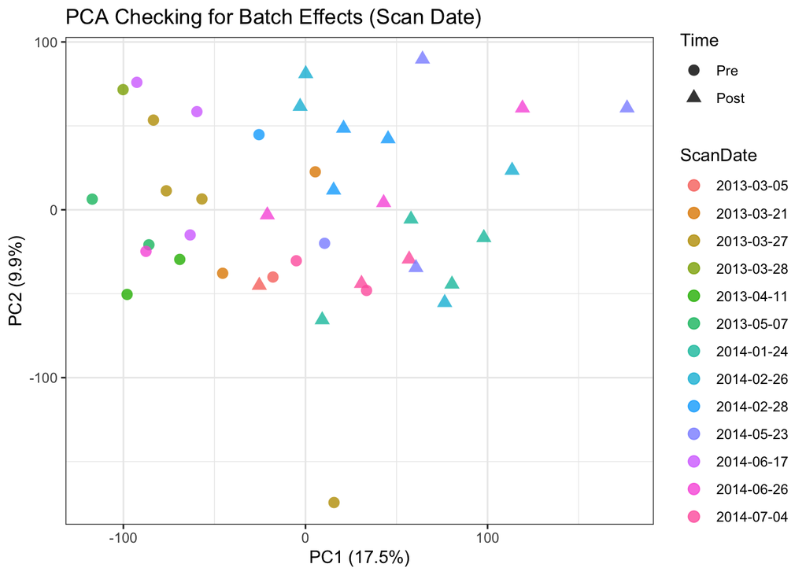

```r
pca_plot_data$ScanDate <- metadata$ScanDate
pca_plot_data$ScanYear <- metadata$ScanYear

ggplot(pca_plot_data, aes(x = PC1, y = PC2, color = ScanDate, shape = Time)) +
  geom_point(size = 3, alpha = 0.8) +
  theme_bw() +
  labs(
    title = "PCA Checking for Batch Effects (Scan Date)",
    x = paste0("PC1 (", round(summary(pca_res)$importance[2,1] * 100, 1), "%)"),
    y = paste0("PC2 (", round(summary(pca_res)$importance[2,2] * 100, 1), "%)")
  )
```

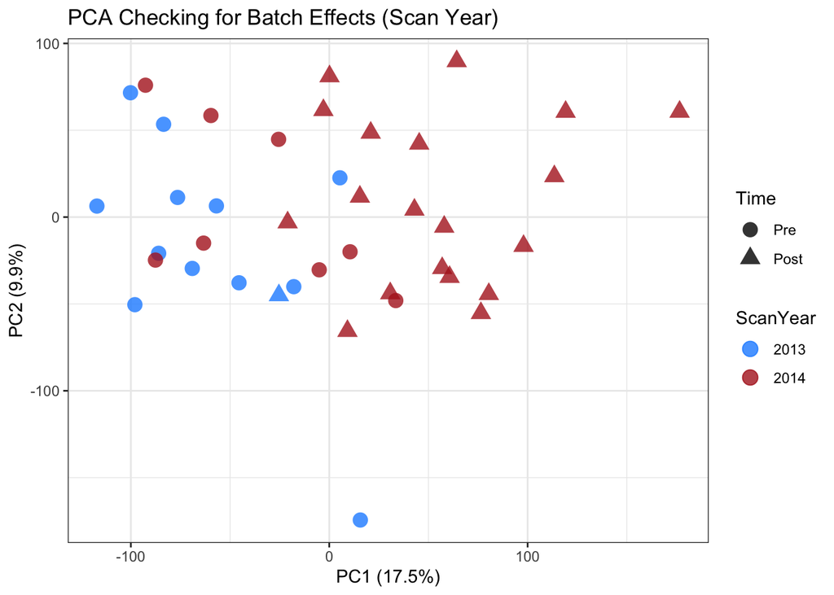

```r
year_colors <- c("2013" = "dodgerblue", "2014" = "firebrick")

ggplot(pca_plot_data, aes(x = PC1, y = PC2, color = ScanYear, shape = Time)) +
  geom_point(size = 4, alpha = 0.8) +
  theme_bw() +
  scale_color_manual(values = year_colors) +
  labs(
    title = "PCA Checking for Batch Effects (Scan Year)",
    x = paste0("PC1 (", round(summary(pca_res)$importance[2,1] * 100, 1), "%)"),
    y = paste0("PC2 (", round(summary(pca_res)$importance[2,2] * 100, 1), "%)")
  )
```

## Batch Effect Correction

```r
metadata$group <- factor(paste(metadata$Disease, metadata$Time, metadata$Sex, sep = "_"))
mod <- model.matrix(~ group, data = metadata)

expression_matrix_filtered <- ComBat(
  dat = expression_matrix_filtered,
  batch = metadata$ScanYear,
  mod = mod,
  par.prior = TRUE
)
```

```
## Found2batches
```

```
## Adjusting for7covariate(s) or covariate level(s)
```

```
## Standardizing Data across genes
```

```
## Fitting L/S model and finding priors
```

```
## Finding parametric adjustments
```

```
## Adjusting the Data
```

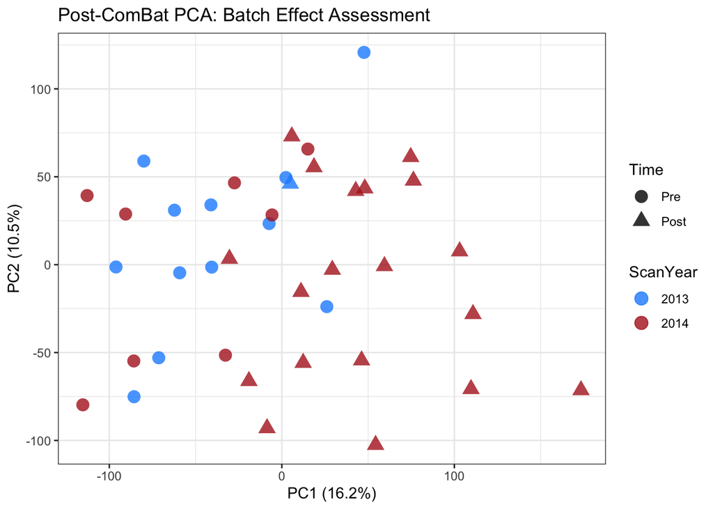

```r
# Re-calculate PCA on the newly scrubbed ComBat matrix
pca_res_post <- prcomp(t(expression_matrix_filtered), scale. = TRUE)
pca_df_post <- as.data.frame(pca_res_post$x)
pca_plot_data_post <- cbind(pca_df_post, metadata)

# Define the batch colors again
year_colors <- c("2013" = "dodgerblue", "2014" = "firebrick")

# Generate the plot
ggplot(pca_plot_data_post, aes(x = PC1, y = PC2, color = ScanYear, shape = Time)) +
  geom_point(size = 4, alpha = 0.8) +
  theme_bw() +
  scale_color_manual(values = year_colors) +
  labs(
    title = "Post-ComBat PCA: Batch Effect Assessment",
    x = paste0("PC1 (", round(summary(pca_res_post)$importance[2,1] * 100, 1), "%)"),
    y = paste0("PC2 (", round(summary(pca_res_post)$importance[2,2] * 100, 1), "%)")
  )
```

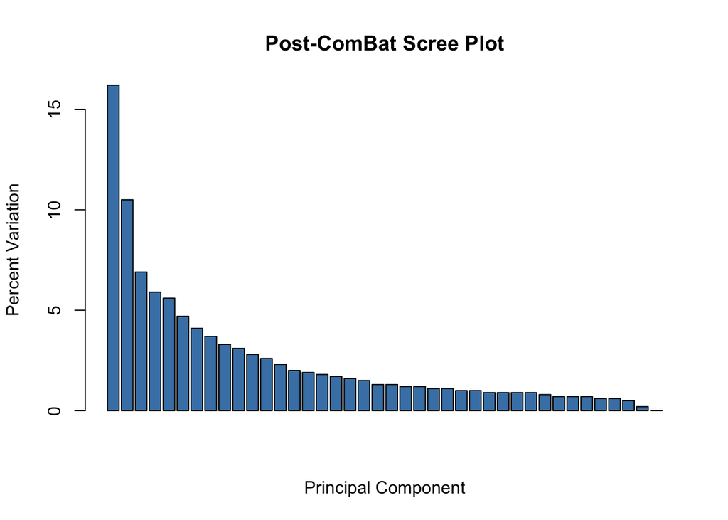

```r
# Combined plot
pca_res_final <- prcomp(t(expression_matrix_filtered), scale. = TRUE)
pca_df_final <- as.data.frame(pca_res_final$x)

# Bind with metadata
pca_plot_data_final <- cbind(pca_df_final, metadata)
pca_res.var_final <- pca_res_final$sdev^2
pca_res.var.per_final <- round(pca_res.var_final/sum(pca_res.var_final)*100, 1)

barplot(pca_res.var.per_final,
        main = "Post-ComBat Scree Plot",
        xlab = "Principal Component",
        ylab = "Percent Variation",
        col = "steelblue")
```

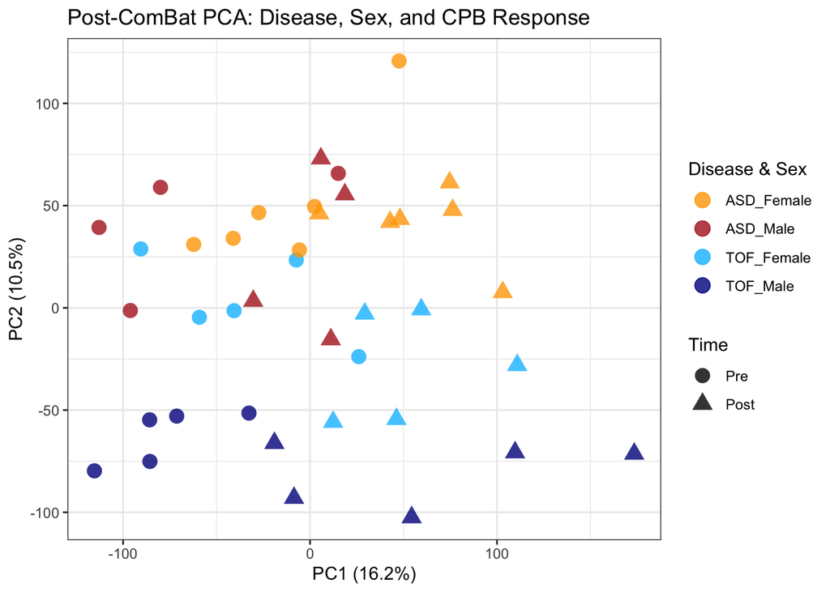

```r
pca_plot_data_final$Disease_Sex <- paste(pca_plot_data_final$Disease, pca_plot_data_final$Sex, sep = "_")

ggplot(pca_plot_data_final, aes(x = PC1, y = PC2, color = Disease_Sex, shape = Time)) +
  geom_point(size = 4, alpha = 0.8) +
  theme_bw() +

  scale_color_manual(
    name = "Disease & Sex",
    values = c(
      "ASD_Female" = "orange",
      "ASD_Male" = "firebrick",
      "TOF_Female" = "deepskyblue",
      "TOF_Male" = "darkblue"
    )
  ) +

  labs(
    title = "Post-ComBat PCA: Disease, Sex, and CPB Response",
    x = paste0("PC1 (", round(summary(pca_res_final)$importance[2,1] * 100, 1), "%)"),
    y = paste0("PC2 (", round(summary(pca_res_final)$importance[2,2] * 100, 1), "%)")
  )
```

## Limma DGE

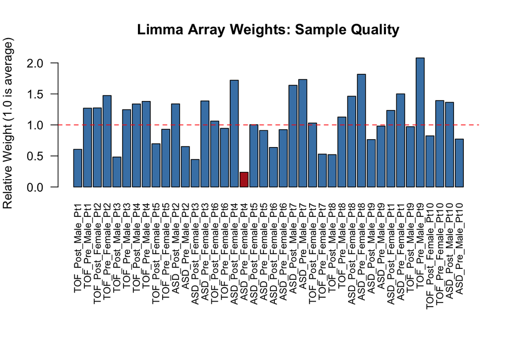

```r
# Primary grouping factor, ex: TOF_Post_Male
metadata$group <- factor(paste(metadata$Disease, metadata$Time, metadata$Sex, sep = "_"))

# Set up design matrix
design <- model.matrix(~0 + group, data = metadata)
colnames(design) <- gsub("group", "", colnames(design))

aw <- arrayWeights(expression_matrix_filtered, design)

# Plot arrayWeights
names(aw) <- colnames(expression_matrix_filtered)
par(mar = c(12, 4, 4, 2))
barplot(aw,
        las = 2,
        names.arg = names(aw), # FIX: Force the plot to use the names
        col = ifelse(grepl("ASD_Pre_Female_Pt4", names(aw)), "firebrick", "steelblue"),
        main = "Limma Array Weights: Sample Quality",
        ylab = "Relative Weight (1.0 is average)",
        cex.names = 0.8)
abline(h = 1, col = "red", lty = 2)
```

```r
par(mar = c(5, 4, 4, 2) + 0.1)

# duplicateCorrelation estimates the internal consistency of each child's samples
corfit <- duplicateCorrelation(expression_matrix_filtered, design, block = metadata$PatientID)

fit <- lmFit(expression_matrix_filtered, design, block = metadata$PatientID, correlation = corfit$consensus, weights = aw)
#fit <- lmFit(expression_matrix_filtered, design, block = metadata$PatientID, correlation = corfit$consensus)

# Create contrasts
contrastMatrix <- makeContrasts(
  TOF_Male_Response = TOF_Post_Male - TOF_Pre_Male,
  TOF_Female_Response = TOF_Post_Female - TOF_Pre_Female,
  ASD_Male_Response = ASD_Post_Male - ASD_Pre_Male,
  ASD_Female_Response = ASD_Post_Female - ASD_Pre_Female,

  # Sex diff
  TOF_Sex_Diff = (TOF_Post_Female - TOF_Pre_Female) - (TOF_Post_Male - TOF_Pre_Male),
  ASD_Sex_Diff = (ASD_Post_Female - ASD_Pre_Female) - (ASD_Post_Male - ASD_Pre_Male),

  levels = design
)

# Final Statistics
fit2 <- contrasts.fit(fit, contrastMatrix)
fit2 <- eBayes(fit2, robust = TRUE)

# View Summaries
resultsSummary <- decideTests(fit2)
print(summary(resultsSummary))
```

```
##        TOF_Male_Response TOF_Female_Response ASD_Male_Response
## Down                1809                 292                38
## NotSig             25354               27175             27961
## Up                   924                 620                88
##        ASD_Female_Response TOF_Sex_Diff ASD_Sex_Diff
## Down                   810            0            0
## NotSig               26786        28087        28087
## Up                     491            0            0
```

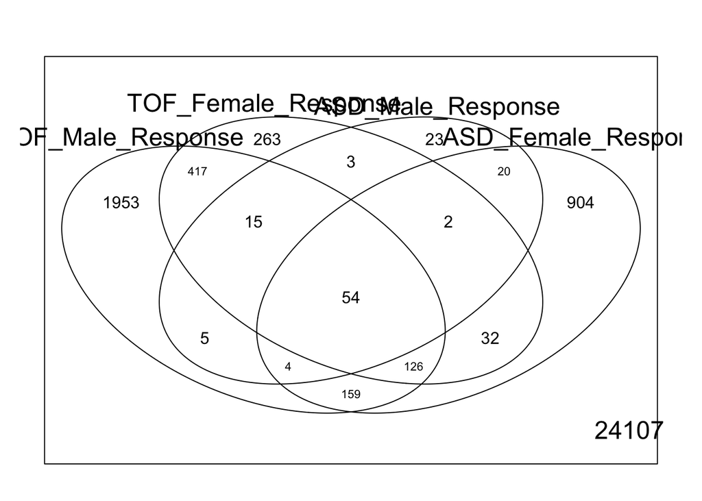

```r
vennDiagram(resultsSummary[, c("TOF_Male_Response", "TOF_Female_Response", "ASD_Male_Response", "ASD_Female_Response")])
```

## Post-Analysis and Result Generation

```r
hgnc_complete_set_df <- read_tsv("hgnc_complete_set.txt") %>%
  dplyr::select(HGNC_Symbol = symbol)
contrasts_list <- colnames(contrastMatrix)
for (contrast_name in contrasts_list) {
  res_df <- topTable(fit2, coef = contrast_name, number = Inf, adjust.method = "BH")

  # Add HGNC gene symbol
  res_df_with_hgnc <- res_df %>%
    as_tibble(rownames = "Original_Probe_ID") %>%
    mutate(HGNC_Symbol = hgnc_symbols_filtered[match(Original_Probe_ID, names(hgnc_symbols_filtered))])

  # Remove rows where HGNC_Symbol is NA
  res_df_with_hgnc <- res_df_with_hgnc %>%
    filter(!is.na(HGNC_Symbol))

  # Perform inner_join with the hgnc_complete_set data
  joined_results <- res_df_with_hgnc %>%
    inner_join(hgnc_complete_set_df %>% dplyr::select(HGNC_Symbol), by = "HGNC_Symbol")

  final_results_table <- joined_results %>%
    dplyr::arrange(adj.P.Val) %>%
    dplyr::distinct(HGNC_Symbol, .keep_all = TRUE)

  final_results_table <- final_results_table %>%
    dplyr::select(HGNC_Symbol, logFC, P.Value, adj.P.Val)

  final_results_table <- final_results_table[!is.na(final_results_table$adj.P.Val), ]

  file_name <- paste0("dge_results_", contrast_name, "_final.csv")
  write_csv(final_results_table, file_name)

  message(paste("Saved:", file_name))
}
```

```
## Saved: dge_results_TOF_Male_Response_final.csv
## Saved: dge_results_TOF_Female_Response_final.csv
## Saved: dge_results_ASD_Male_Response_final.csv
## Saved: dge_results_ASD_Female_Response_final.csv
## Saved: dge_results_TOF_Sex_Diff_final.csv
## Saved: dge_results_ASD_Sex_Diff_final.csv
```

## Post Analysis QC

Calculate Cook’s distances, compared model with and without weights to ensure weights have the intended effect.

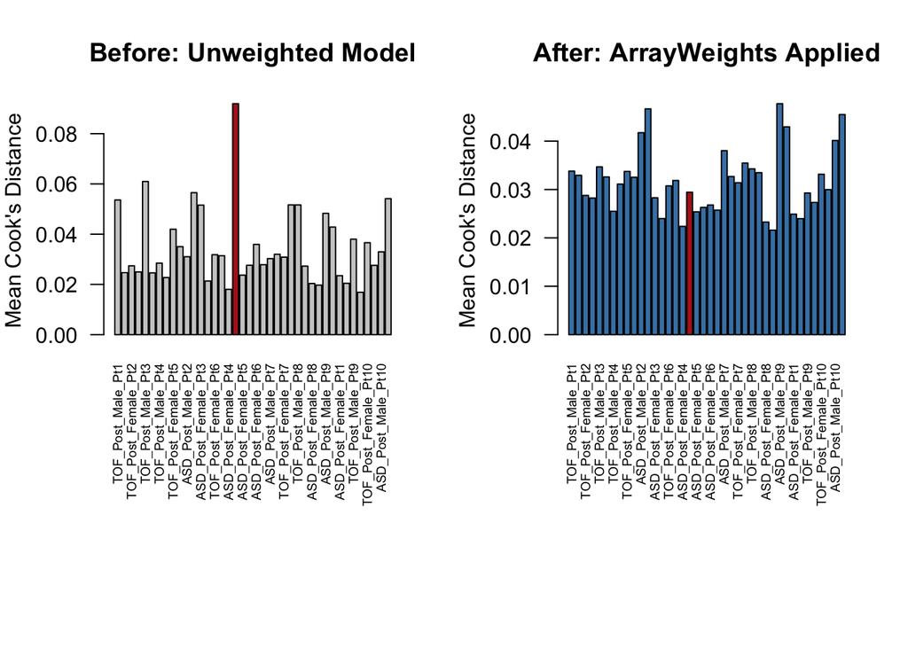

```r
# Unweighted fit
fit_unweighted <- lmFit(expression_matrix_filtered, design,
                        block = metadata$PatientID,
                        correlation = corfit$consensus)

# Calculate Leverages (Hat Matrix)
# Since the design matrix is the same for both, leverage is constant
hat_matrix <- design %*% solve(t(design) %*% design) %*% t(design)
leverages <- diag(hat_matrix)
p <- ncol(design)

# Extract Residuals for both weighted and unweighted models
resids_un <- residuals(fit_unweighted, expression_matrix_filtered)
resids_wt <- residuals(fit, expression_matrix_filtered)

# Calculate Cook's Distance Matrix unweighted
cooks_un <- sweep(resids_un^2, 1, (p * fit$sigma^2), "/")
cooks_un <- sweep(cooks_un, 2, (leverages / (1 - leverages)^2), "*")
mean_cooks_un <- colMeans(cooks_un, na.rm = TRUE)

# Calculate Cook's Distance Matrix weighted
cooks_wt <- sweep(resids_wt^2, 1, (p * fit$sigma^2), "/")
# The residual is scaled by the weight of the array
cooks_wt <- sweep(cooks_wt, 2, (leverages / (1 - leverages)^2) * aw, "*")
mean_cooks_wt <- colMeans(cooks_wt, na.rm = TRUE)

# Set up a 1x2 plotting grid and expand the bottom margins
par(mfrow = c(1, 2), mar = c(12, 4, 4, 2))
threshold <- 4 / ncol(expression_matrix_filtered) # 4/n threshold

# Unweighted
barplot(mean_cooks_un,
        las = 2,
        main = "Before: Unweighted Model",
        ylab = "Mean Cook's Distance",
        col = ifelse(names(mean_cooks_un) == "ASD_Pre_Female_Pt4", "firebrick", "gray80"),
        cex.names = 0.6)
abline(h = threshold, col = "red", lty = 2, lwd = 2)

# Weighted
barplot(mean_cooks_wt,
        las = 2,
        main = "After: ArrayWeights Applied",
        ylab = "Mean Cook's Distance",
        col = ifelse(names(mean_cooks_wt) == "ASD_Pre_Female_Pt4", "firebrick", "steelblue"),
        cex.names = 0.6)
abline(h = threshold, col = "red", lty = 2, lwd = 2)
```

```r
# Reset plotting parameters
par(mfrow = c(1, 1), mar = c(5, 4, 4, 2) + 0.1)
```